# Cargar base de datos

```python
# Importar Librerías
import os
import pandas as pd
import numpy as np
from scipy import stats
import matplotlib.pyplot as plt
import seaborn as sns

# Obtener la ruta del directorio actual
current_directory = os.path.dirname(_file) if "file_" in locals() else os.getcwd()

# Construir la ruta al archivo xlsx
file_path = os.path.join(current_directory, 'base.xlsx')

# Cargar el archivo xlsx en un DataFrame
df = pd.read_excel(file_path)
```

# Primeras cinco filas

```python
# Se imprimen las primeras cinco filas de la base de datos

df.head(5)
```

|  | age | job | marital | education | default | balance | housing | loan | contact | day | month | duration | campaign | pdays | previous | poutcome | y |
| --- | --- | --- | --- | --- | --- | --- | --- | --- | --- | --- | --- | --- | --- | --- | --- | --- | --- |
| 0 | 58 | management | married | tertiary | no | 2143 | yes | no | unknown | 5 | may | 261 | 1 | -1 | 0 | unknown | no |
| 1 | 44 | technician | single | secondary | no | 29 | yes | no | unknown | 5 | may | 151 | 1 | -1 | 0 | unknown | no |
| 2 | 33 | entrepreneur | married | secondary | no | 2 | yes | yes | unknown | 5 | may | 76 | 1 | -1 | 0 | unknown | no |
| 3 | 47 | blue-collar | married | unknown | no | 1506 | yes | no | unknown | 5 | may | 92 | 1 | -1 | 0 | unknown | no |
| 4 | 33 | unknown | single | unknown | no | 1 | no | no | unknown | 5 | may | 198 | 1 | -1 | 0 | unknown | no |

```python
df.shape
```

```
(45211, 17)
```

```python
df.info()
```

```
<class 'pandas.core.frame.DataFrame'>
RangeIndex: 45211 entries, 0 to 45210
Data columns (total 17 columns):
 #   Column     Non-Null Count  Dtype
---  ------     --------------  -----
 0   age        45211 non-null  int64
 1   job        45211 non-null  object
 2   marital    45211 non-null  object
 3   education  45211 non-null  object
 4   default    45211 non-null  object
 5   balance    45211 non-null  int64
 6   housing    45211 non-null  object
 7   loan       45211 non-null  object
 8   contact    45211 non-null  object
 9   day        45211 non-null  int64
 10  month      45211 non-null  object
 11  duration   45211 non-null  int64
 12  campaign   45211 non-null  int64
 13  pdays      45211 non-null  int64
 14  previous   45211 non-null  int64
 15  poutcome   45211 non-null  object
 16  y          45211 non-null  object
dtypes: int64(7), object(10)
memory usage: 5.9+ MB
```

# Resumen variables cuantitativas

```python
def resumen_estadistico(variables, base):
    '''
    Genera un resumen estadístico con medidas descriptivas para variables numéricas seleccionadas.

    Parameters
    ----------
    variables : list of str
        Lista con los nombres de las columnas numéricas para calcular el resumen estadístico.
    base : pandas.DataFrame
        Base de datos en formato DataFrame

    Returns
    -------
    resumen : pandas.DataFrame
        DataFrame con las estadísticas: mínimo, cuartil 1 (Q1), mediana, cuartil 3 (Q3),
        máximo y promedio para cada variable.
    '''

    # Crear tabla con índice de las estadísticas
    resumen = pd.DataFrame(index=[
        'Mínimo', 'Q1', 'Mediana', 'Q3', 'Máximo', 'Promedio'
    ])

    # Calcular las estadísticas para cada variable
    for var in variables:
        resumen[var] = [
            base[var].min(),
            base[var].quantile(0.25),
            base[var].median(),
            base[var].quantile(0.75),
            base[var].max(),
            base[var].mean()
        ]

    # Transponer y redondear la tabla para una mejor visualización
    resumen = resumen.T
    resumen = resumen.round(2)

    return resumen
```

```python
# Seleccionar las variable cuantitativas
variables = [
    'age',
    'balance',
    'duration',
    'campaign',
    'pdays',
    'previous'
]

resumen = resumen_estadistico(variables, df)
print(resumen)
```

```
          Mínimo     Q1  Mediana      Q3    Máximo  Promedio
age         18.0   33.0     39.0    48.0      95.0     40.94
balance  -8019.0   72.0    448.0  1428.0  102127.0   1362.27
duration     0.0  103.0    180.0   319.0    4918.0    258.16
campaign     1.0    1.0      2.0     3.0      63.0      2.76
pdays       -1.0   -1.0     -1.0    -1.0     871.0     40.20
previous     0.0    0.0      0.0     0.0     275.0      0.58
```

# Gráficos Variables Cuantitativas

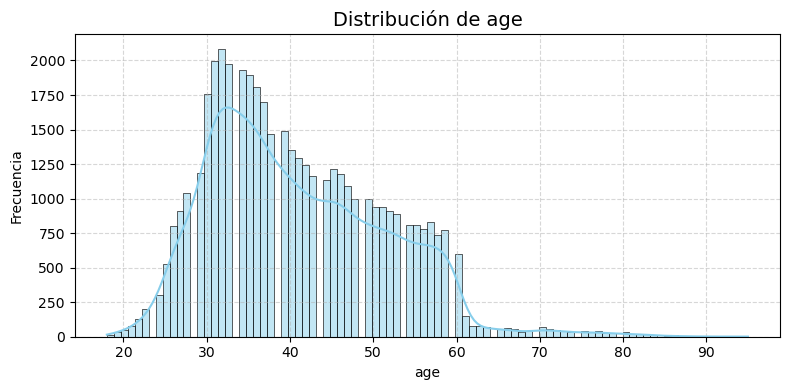

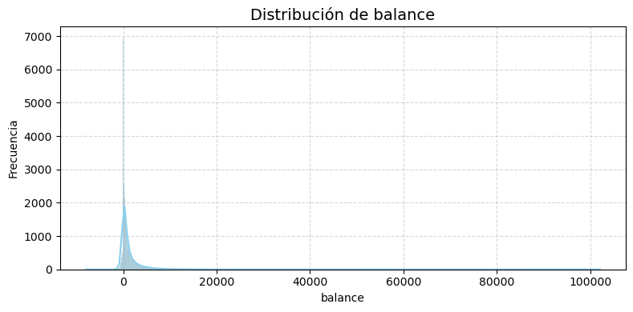

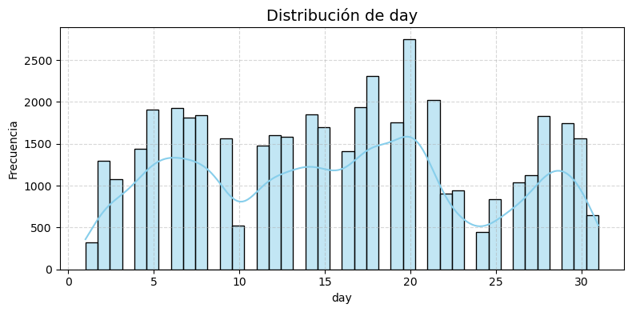

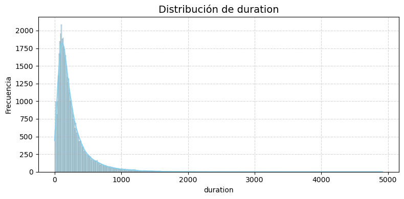

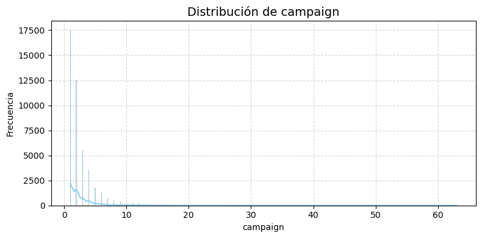

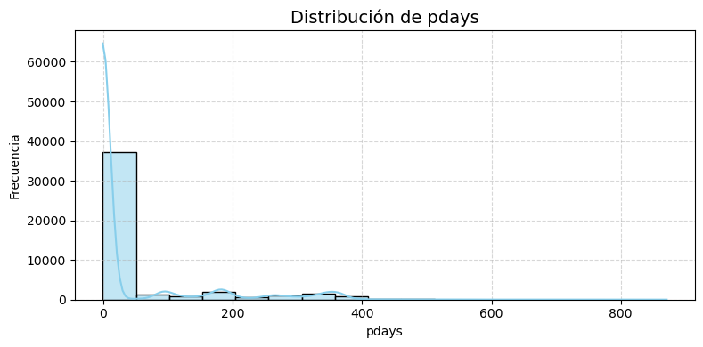

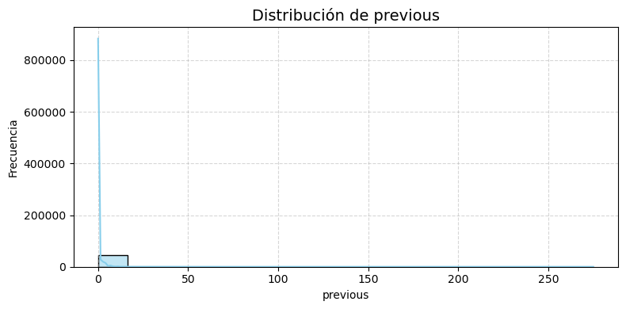

```python
# Incluir sólo variables cuantitativas
cuantitativas = df.select_dtypes(include=['int64', 'float64'])

# Graficar histogramas de cada variable
for col in cuantitativas.columns:
    plt.figure(figsize=(8,4))
    sns.histplot(df[col], kde = True, color = 'skyblue', edgecolor = 'black')
    plt.title(f'Distribución de {col}', fontsize = 14)
    plt.xlabel(col)
    plt.ylabel('Frecuencia')
    plt.grid(True, linestyle='--',alpha = 0.5)
    plt.tight_layout()
    plt.savefig(f"distribucion_{col}.png")
    plt.show()
```

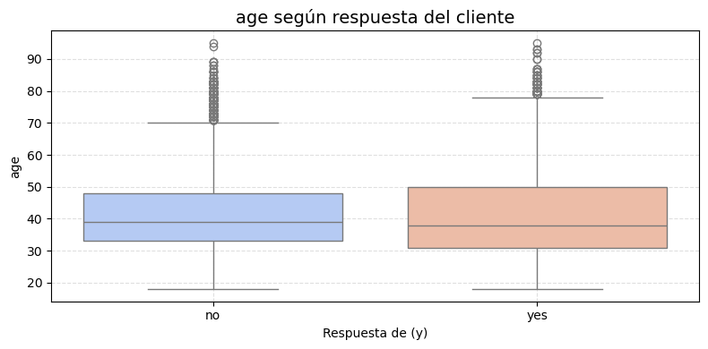

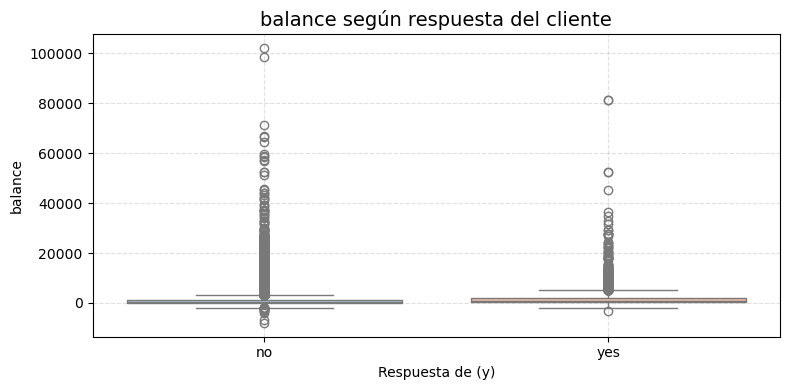

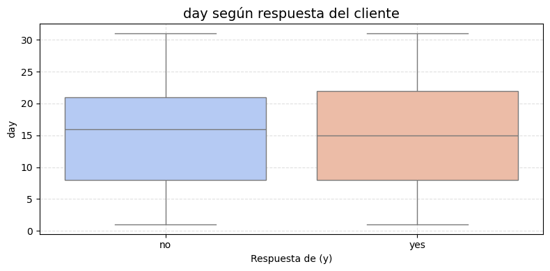

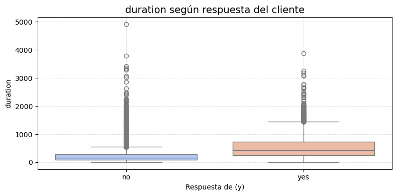

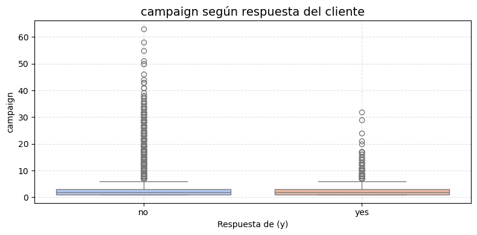

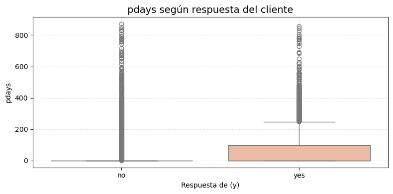

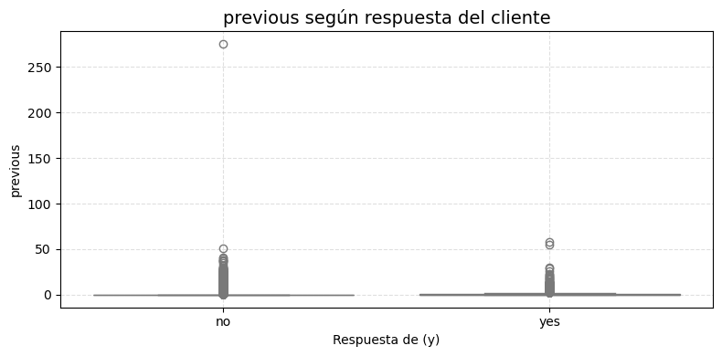

```python
# Graficar boxplots de cada variable
for col in cuantitativas.columns:
    plt.figure(figsize=(8,4))
    sns.boxplot(data = df, x = 'y', y = col, palette = 'coolwarm')
    plt.title(f'{col} según respuesta del cliente', fontsize = 14)
    plt.xlabel('Respuesta de (y)')
    plt.ylabel(col)
    plt.grid(True, linestyle='--',alpha = 0.4)
    plt.tight_layout()
    plt.show()
```

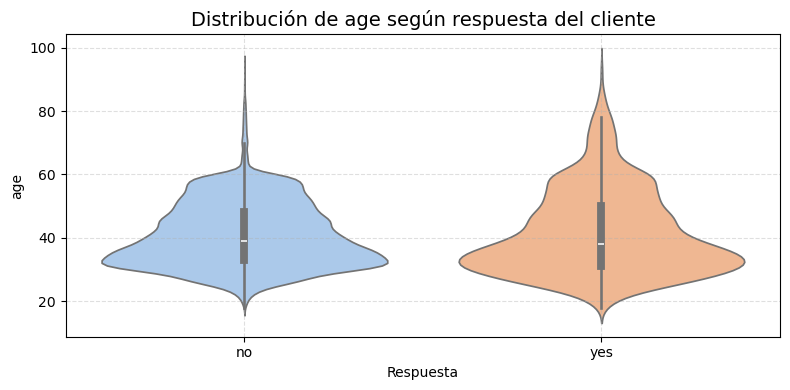

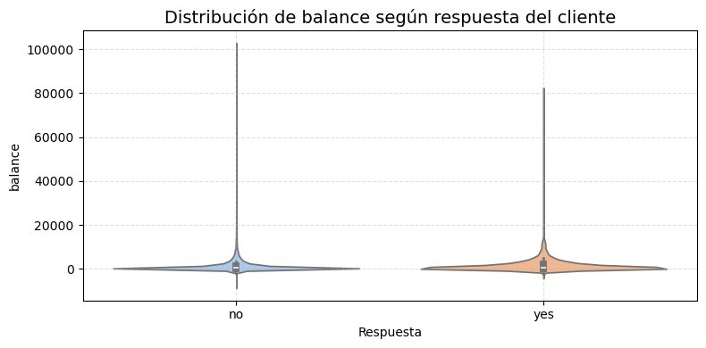

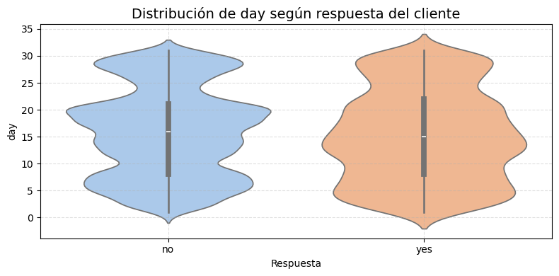

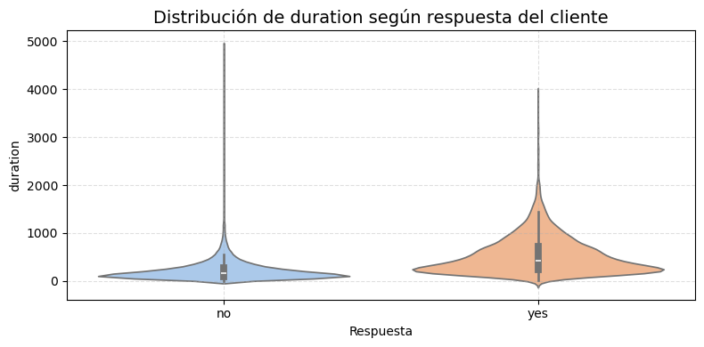

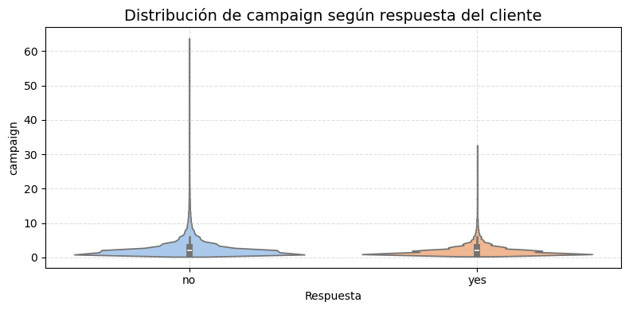

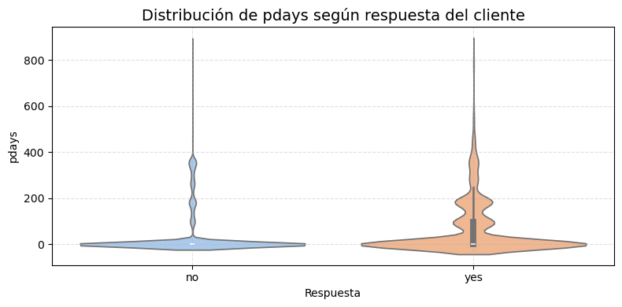

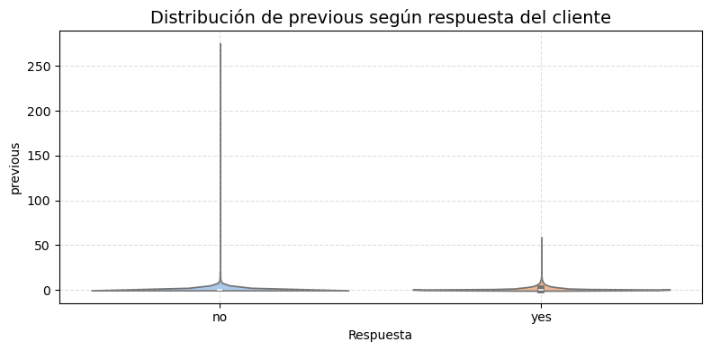

```python
# Gráficos de violnes para cada variable
for col in cuantitativas.columns:
    plt.figure(figsize=(8,4))
    sns.violinplot(data = df, x = 'y', y = col, palette = 'pastel')
    plt.title(f'Distribución de {col} según respuesta del cliente',  fontsize = 14)
    plt.xlabel('Respuesta')
    plt.ylabel(col)
    plt.grid(True, linestyle='--',alpha = 0.4)
    plt.tight_layout()
    plt.savefig(f"distribuviolin_{col}.png")
    plt.show()
```

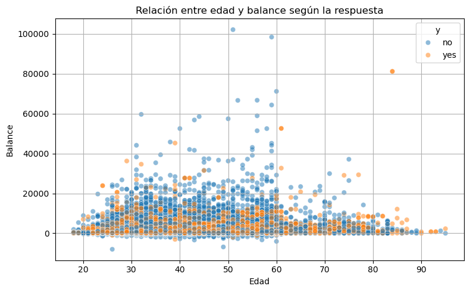

```python
# Diagrama de dispersión de cada variable
plt.figure(figsize=(8, 5))
sns.scatterplot(data=df, x='age', y='balance', hue='y', alpha=0.5)
plt.title('Relación entre edad y balance según la respuesta')
plt.xlabel('Edad')
plt.ylabel('Balance')
plt.grid(True)
plt.tight_layout()
plt.savefig(f"edad_balance_respuesta.png")
plt.show()
```

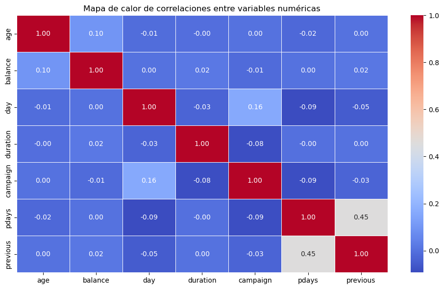

```python
# Seleccionar solo las columnas numéricas
df_numeric = df.select_dtypes(include=['int64', 'float64'])

# Calcular la matriz de correlación
correlation_matrix = df_numeric.corr()

# Crear el mapa de calor
plt.figure(figsize=(10, 6))
sns.heatmap(correlation_matrix, annot=True, cmap='coolwarm', fmt=".2f", linewidths=0.5)
plt.title("Mapa de calor de correlaciones entre variables numéricas")
plt.tight_layout()
plt.savefig(f"mapa_color.png")
plt.show()
```

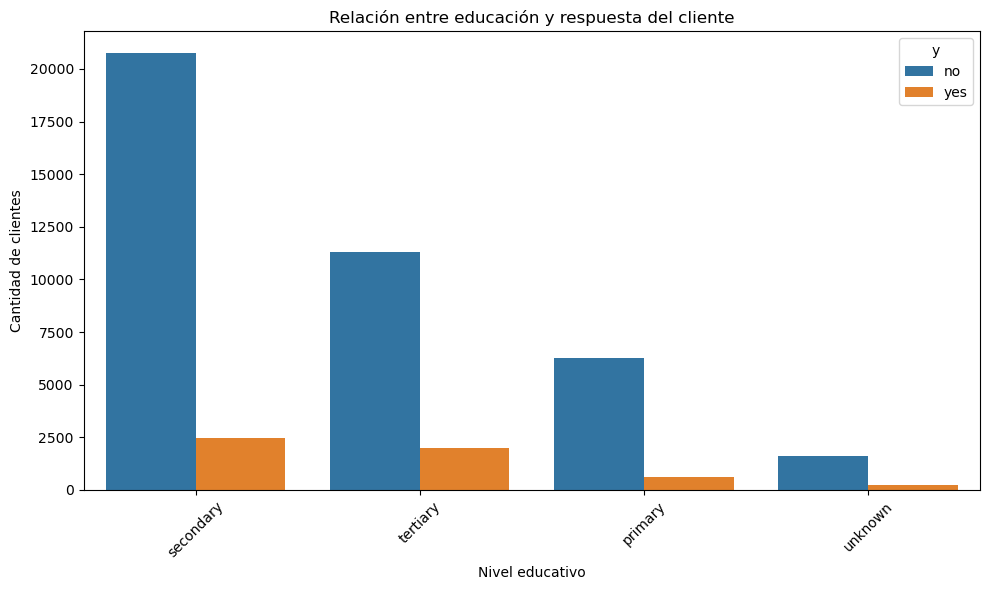

```python
# Gráfico de barras entre eduación y repsuesta de cliente
plt.figure(figsize=(10, 6))
sns.countplot(data=df, x='education', hue='y', order=df['education'].value_counts().index)
plt.xticks(rotation=45)
plt.title('Relación entre educación y respuesta del cliente')
plt.xlabel('Nivel educativo')
plt.ylabel('Cantidad de clientes')
plt.tight_layout()
plt.show()
```

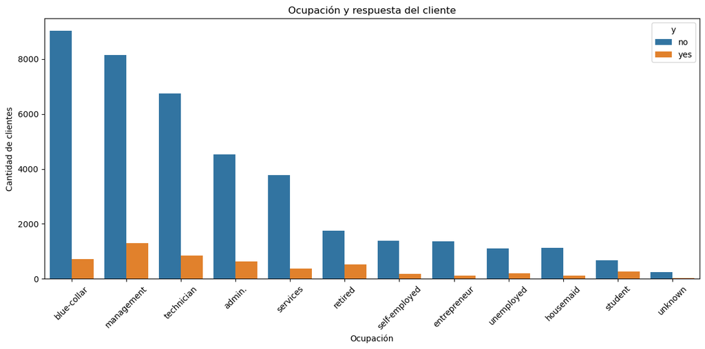

```python
# Gráfico de barras entre ocupación y respuesta del cliente
plt.figure(figsize=(12, 6))
sns.countplot(data=df, x='job', hue='y', order=df['job'].value_counts().index)
plt.xticks(rotation=45)
plt.title('Ocupación y respuesta del cliente')
plt.xlabel('Ocupación')
plt.ylabel('Cantidad de clientes')
plt.tight_layout()
plt.show()
```

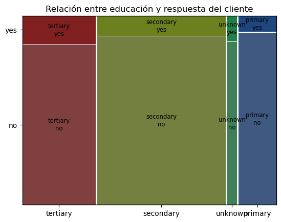

```python
# Mosaico entre educación y respuesta del cliente
from statsmodels.graphics.mosaicplot import mosaic

mosaic(df, ['education', 'y'])
plt.title('Relación entre educación y respuesta del cliente')
plt.show()
```

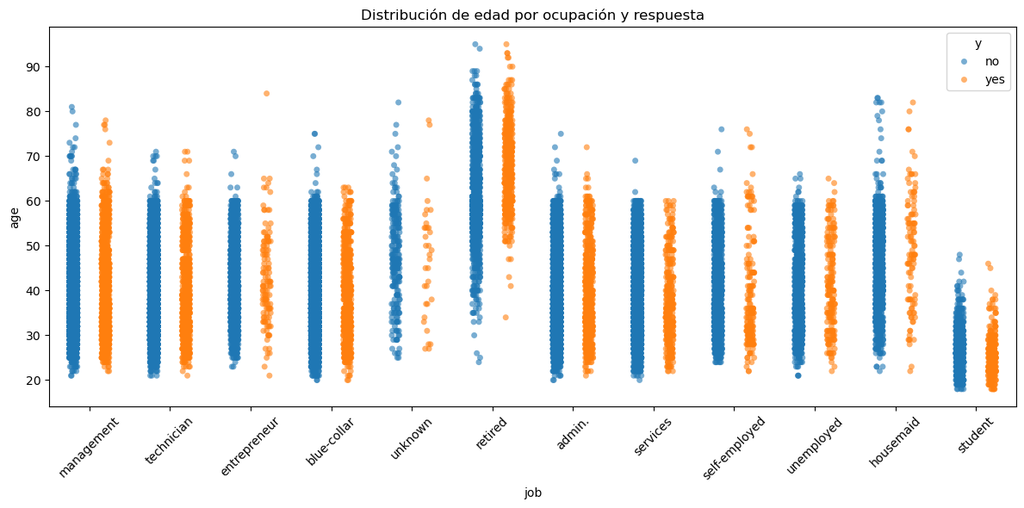

```python
plt.figure(figsize=(12, 6))
sns.stripplot(data=df, x='job', y='age', hue='y', dodge=True, alpha=0.6)
plt.xticks(rotation=45)
plt.title('Distribución de edad por ocupación y respuesta')
plt.tight_layout()
plt.show()
```

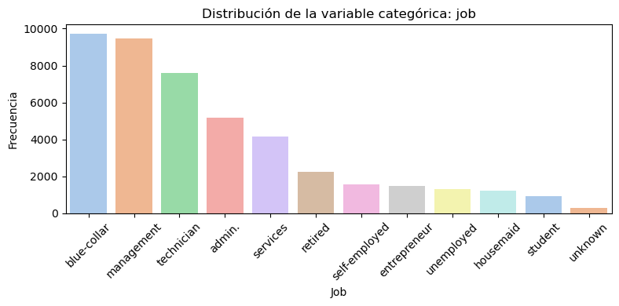

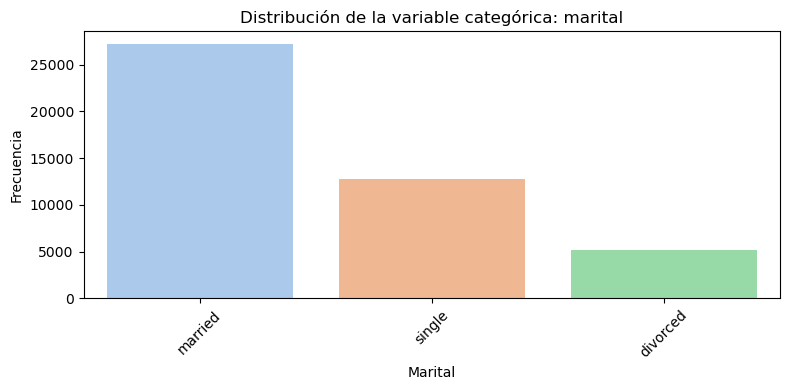

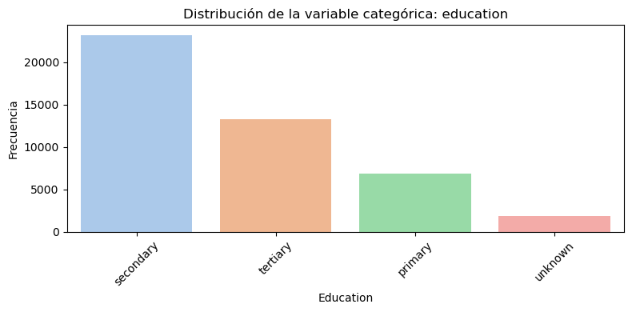

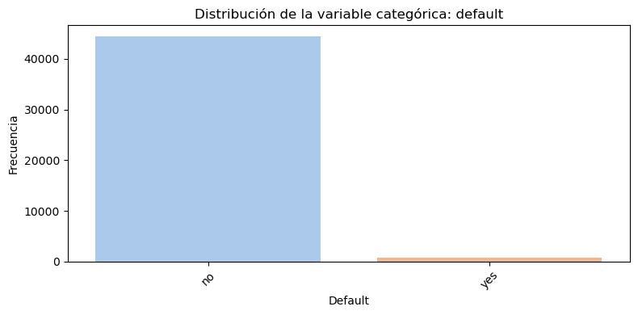

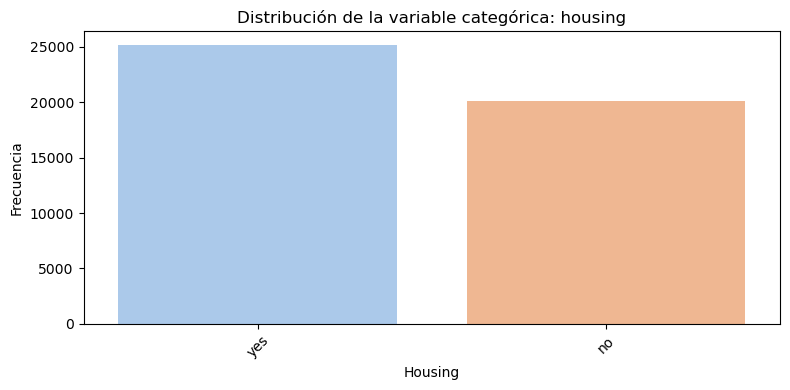

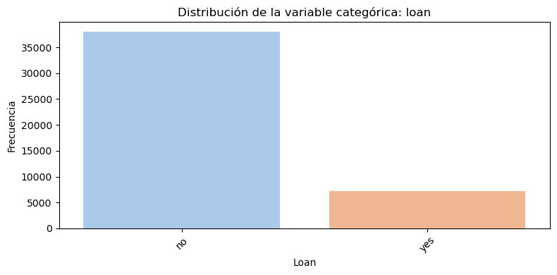

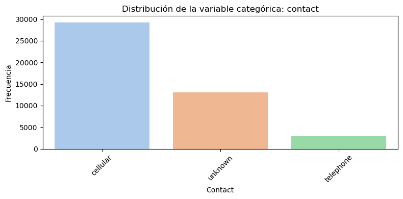

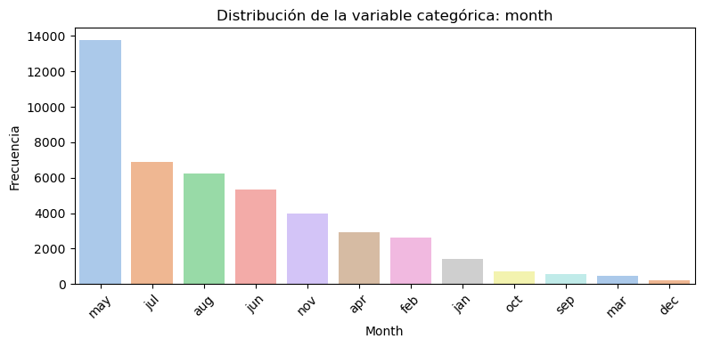

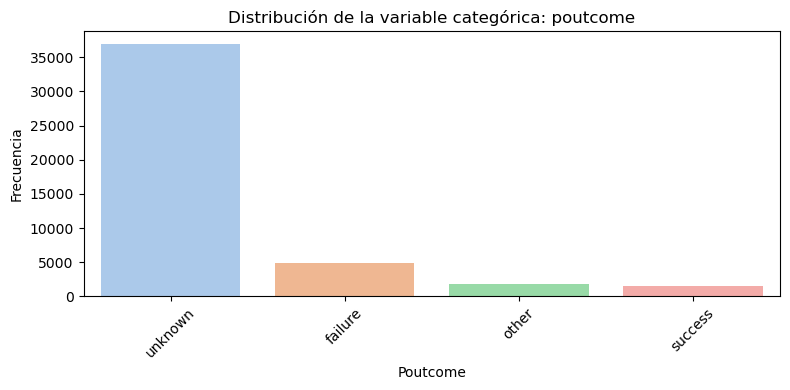

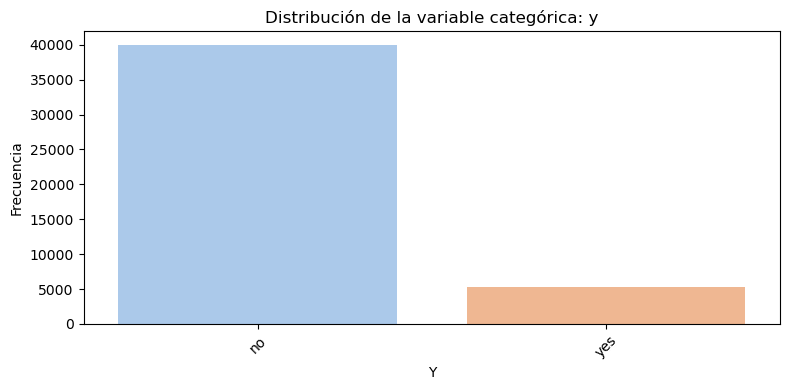

```python
# Filtrar variables categóricas
categoricas = df.select_dtypes(include='object').columns

# Crear un gráfico para cada una
for col in categoricas:
    plt.figure(figsize=(8, 4))
    sns.countplot(data=df, x=col, order=df[col].value_counts().index, palette='pastel')
    plt.title(f'Distribución de la variable categórica: {col}')
    plt.xlabel(col.capitalize())
    plt.ylabel('Frecuencia')
    plt.xticks(rotation=45)
    plt.tight_layout()
    plt.savefig(f"categorica_{col}.png")
    plt.show()
```

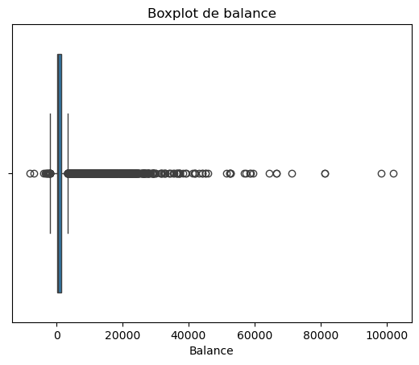

```python
sns.boxplot(x=df['balance'])
plt.title('Boxplot de balance')
plt.xlabel('Balance')
plt.show()
```

```python
for col in df.columns:
    print(f"{col}: {(df[col] == 'unknown').sum()} valores 'unknown'")
```

```
age: 0 valores 'unknown'
job: 288 valores 'unknown'
marital: 0 valores 'unknown'
education: 1857 valores 'unknown'
default: 0 valores 'unknown'
balance: 0 valores 'unknown'
housing: 0 valores 'unknown'
loan: 0 valores 'unknown'
contact: 13020 valores 'unknown'
day: 0 valores 'unknown'
month: 0 valores 'unknown'
duration: 0 valores 'unknown'
campaign: 0 valores 'unknown'
pdays: 0 valores 'unknown'
previous: 0 valores 'unknown'
poutcome: 36959 valores 'unknown'
y: 0 valores 'unknown'
```

# Ajuste de modelo

```python
# Primer paso: dividir las columnas en dos tipos de variables: dependientes e independientes
var_indep = ['job', 'marital', 'education', 'default','balance','housing','loan','contact','day','month','duration','campaign','pdays','previous','poutcome']
X = df[var_indep] # Variables Independientes
# Al tener variables categóricas, se convierten a numéricas
X = pd.get_dummies(X, drop_first=True)

y = df.y # Variable Objetivo
# La variable dependiente 'y' es categórica como 'yes' o 'no', por lo que se convierte a valores binarios
y = y.map({'no': 0, 'yes': 1})
```

```python
X.head()
```

|  | balance | day | duration | campaign | pdays | previous | job_blue-collar | job_entrepreneur | job_housemaid | job_management | ... | month_jul | month_jun | month_mar | month_may | month_nov | month_oct | month_sep | poutcome_other | poutcome_success | poutcome_unknown |
| --- | --- | --- | --- | --- | --- | --- | --- | --- | --- | --- | --- | --- | --- | --- | --- | --- | --- | --- | --- | --- | --- |
| 0 | 2143 | 5 | 261 | 1 | -1 | 0 | False | False | False | True | ... | False | False | False | True | False | False | False | False | False | True |
| 1 | 29 | 5 | 151 | 1 | -1 | 0 | False | False | False | False | ... | False | False | False | True | False | False | False | False | False | True |
| 2 | 2 | 5 | 76 | 1 | -1 | 0 | False | True | False | False | ... | False | False | False | True | False | False | False | False | False | True |
| 3 | 1506 | 5 | 92 | 1 | -1 | 0 | True | False | False | False | ... | False | False | False | True | False | False | False | False | False | True |
| 4 | 1 | 5 | 198 | 1 | -1 | 0 | False | False | False | False | ... | False | False | False | True | False | False | False | False | False | True |

5 rows × 41 columns

```python
# Segundo paso: Dividir base de datos en conjunto de entrenamiento y de prueba

# Se dividen X y y en los sets de entrenamiento y de prueba
from sklearn.model_selection import train_test_split
from sklearn.pipeline import Pipeline
from sklearn.preprocessing import StandardScaler
from sklearn.linear_model import LogisticRegression
from sklearn.metrics import confusion_matrix, classification_report

# Se usa un radio de 75:25, es decir, 75% de los datos va a ser usados en el modelo de entrenamiento y 25% para el modelo de prueba
X_train, X_test, y_train, y_test = train_test_split(X, y, test_size=0.25, random_state=16)

# Se realiza un escalado de las variables por medio de un pipeline, ya que de otra manera el algoritmo no converge
pipe = Pipeline([
    ('scaler', StandardScaler()),               # Escala los datos (media 0, varianza 1)
    ('logreg', LogisticRegression(random_state=16, max_iter=1000))  # Modelo
])
```

```python
# Tercer paso: Importar modelo LogisticRegression y ajustar el modelo en el set de entrenamiento

from sklearn import metrics

# Ajustar el modelo con los datos
pipe.fit(X_train, y_train)
```

```
Pipeline(steps=[('scaler', StandardScaler()),
                ('logreg', LogisticRegression(max_iter=1000, random_state=16))])
```

```python
# Cuarto paso: Predecir

y_pred = pipe.predict(X_test)
```

```python
# Quinto paso: Evaluar

matriz_conf = metrics.confusion_matrix(y_test, y_pred)
matriz_conf
```

```
array([[9701,  231],
       [ 904,  467]], dtype=int64)
```

9701: modelo predijo 'no', y era 'no'

231: modelo predijo 'yes', pero era 'no'

904: modelo predijo 'no', pero era 'yes'

467: modelo predijo 'yes', y era 'yes'

```python
print(classification_report(y_test, y_pred))
```

```
              precision    recall  f1-score   support

           0       0.91      0.98      0.94      9932
           1       0.67      0.34      0.45      1371

    accuracy                           0.90     11303
   macro avg       0.79      0.66      0.70     11303
weighted avg       0.88      0.90      0.88     11303
```

91% de los que predijo como no, realmente eran no.

Modelo detectó correctamente 98% de los no.

Muy buen balance entre precisión y recall.

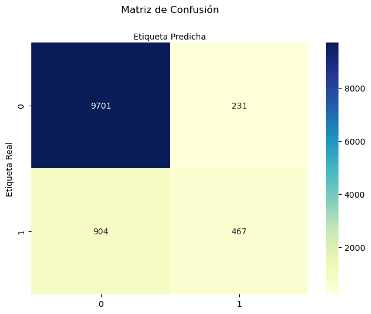

```python
# import required modules
import numpy as np
import matplotlib.pyplot as plt
import seaborn as sns

nombres_clases = [0,1]
fig, ax = plt.subplots()
marcas_ver = np.arange(len(nombres_clases))
plt.xticks(marcas_ver, nombres_clases)
plt.yticks(marcas_ver, nombres_clases)

# Mapa de calor
sns.heatmap(pd.DataFrame(matriz_conf), annot=True, cmap="YlGnBu" ,fmt='g')
ax.xaxis.set_label_position("top")
plt.tight_layout()
plt.title('Matriz de Confusión', y=1.1)
plt.ylabel('Etiqueta Real')
plt.xlabel('Etiqueta Predicha')
```

Modelo es muy bueno prediciendo los no, lo cual es común en conjuntos desbalanceados. Tiene dificultades para detectar los sí.

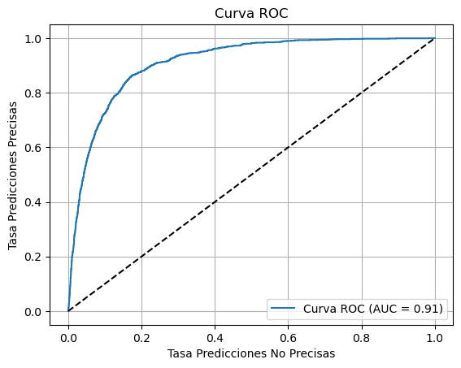

```python
# Curva ROC: compara tasa de predicciones precisas y las no precisas
# Muestra equilibrio entre sensibilidad y especificidad

# Obtener las probabilidades predichas para la clase positiva (1)
y_pred_proba = pipe.predict_proba(X_test)[:, 1]

# Calcular FPR, TPR y AUC
fpr, tpr, _ = metrics.roc_curve(y_test, y_pred_proba)
auc = metrics.roc_auc_score(y_test, y_pred_proba)

# Graficar curva ROC
plt.figure()
plt.plot(fpr, tpr, label="Curva ROC (AUC = {:.2f})".format(auc))
plt.plot([0, 1], [0, 1], 'k--')  # línea diagonal (azar)
plt.xlabel('Tasa Predicciones No Precisas')
plt.ylabel('Tasa Predicciones Precisas')
plt.title('Curva ROC')
plt.legend(loc="lower right")
plt.grid()
plt.show()
```

Como el objetivo del proyecto es identificar las variables más relevantes que influyen en la decisión de los clientes, se procede a analizar los coeficientes del modelo

```python
# Extraer nombres de variables
feature_names = X.columns

# Extraer coeficientes del modelo dentro del pipeline (el entrenado)
coeffs = pipe.named_steps['logreg'].coef_[0]

# Combinar en un DataFrame
coef_df = pd.DataFrame({
    'Variable': feature_names,
    'Coeficiente': coeffs,
    'Odds Ratio': np.exp(coeffs)
}).sort_values(by='Odds Ratio', ascending=False)

# Coeficiente: peso que el modelo le asigna a esa variable en el cálculo del logit
# Odds ratio: Cuánto multiplica las probabilidades de clase 1 cuando xi aumenta una unidad
# > 1.0 -> aumenta probabilidad de decir sí
# = 1.0 -> no afecta significativamente la probabilidad
# < 1.0 -> disminuye la probabilidad de decir sí
print(coef_df)
```

```
               Variable  Coeficiente  Odds Ratio
2              duration     1.078643    2.940686
39     poutcome_success     0.390486    1.477698
20   education_tertiary     0.189752    1.208950
33            month_mar     0.163480    1.177602
32            month_jun     0.144554    1.155524
19  education_secondary     0.121400    1.129077
36            month_oct     0.114514    1.121329
1                   day     0.094220    1.098801
37            month_sep     0.086920    1.090810
13          job_student     0.063095    1.065128
10          job_retired     0.056917    1.058568
21    education_unknown     0.051775    1.053138
28            month_dec     0.046273    1.047360
0               balance     0.033158    1.033714
```

[output cut: 27 more lines]

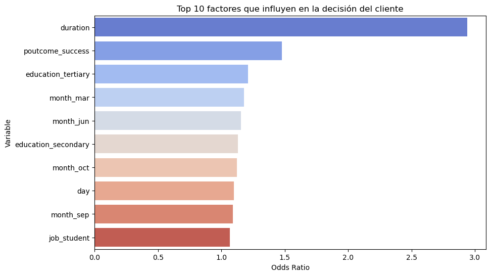

```python
top_vars = coef_df.sort_values(by='Odds Ratio', ascending=False).head(10)

plt.figure(figsize=(10,6))
sns.barplot(data=top_vars, x='Odds Ratio', y='Variable', palette='coolwarm')
plt.title("Top 10 factores que influyen en la decisión del cliente")
plt.xlabel("Odds Ratio")
plt.ylabel("Variable")
plt.show()
```

Asimismo, con job_student, los estudiantes tienen una probabilidad ligeramente mayor de aceptar una oferta. Esto se puede relacionar con apertura a nuevas propuestas o productos simples.

```python
# Encontrar p-values con statsmodels para ver si los coeficientes son estadísticamente significativos
import statsmodels.api as sm

# Asegurar que todas las columnas sean tipo float
X_const = sm.add_constant(X).astype(float)
y = y.astype(float)
model = sm.Logit(y, X_const)
result = model.fit()
print(result.summary())
```

```
Optimization terminated successfully.
         Current function value: 0.238463
         Iterations 8
                           Logit Regression Results
==============================================================================
Dep. Variable:                      y   No. Observations:                45211
Model:                          Logit   Df Residuals:                    45169
Method:                           MLE   Df Model:                           41
Date:                Thu, 08 May 2025   Pseudo R-squ.:                  0.3392
Time:                        13:56:47   Log-Likelihood:                -10781.
converged:                       True   LL-Null:                       -16315.
Covariance Type:            nonrobust   LLR p-value:                     0.000
=======================================================================================
                          coef    std err          z      P>|z|      [0.025      0.975]
---------------------------------------------------------------------------------------
const                  -2.5303      0.151    -16.806      0.000      -2.825      -2.235
balance              1.285e-05   5.13e-06      2.504      0.012    2.79e-06    2.29e-05
day                     0.0100      0.002      3.993      0.000       0.005       0.015
duration                0.0042   6.45e-05     64.985      0.000       0.004       0.004
campaign               -0.0908      0.010     -8.955      0.000      -0.111      -0.071
pdays                  -0.0001      0.000     -0.336      0.737      -0.001       0.000
previous                0.0102      0.007      1.561      0.118      -0.003       0.023
job_blue-collar        -0.3100      0.073     -4.268      0.000      -0.452      -0.168
job_entrepreneur       -0.3569      0.125     -2.844      0.004      -0.603      -0.111
job_housemaid          -0.5035      0.136     -3.701      0.000      -0.770      -0.237
job_management         -0.1651      0.073     -2.255      0.024      -0.309      -0.022
job_retired             0.2545      0.087      2.912      0.004       0.083       0.426
job_self-employed      -0.2983      0.112     -2.663      0.008      -0.518      -0.079
job_services           -0.2239      0.084     -2.664      0.008      -0.389      -0.059
job_student             0.3811      0.107      3.559      0.000       0.171       0.591
job_technician         -0.1760      0.069     -2.554      0.011      -0.311      -0.041
job_unemployed         -0.1766      0.112     -1.582      0.114      -0.395       0.042
job_unknown            -0.3127      0.233     -1.341      0.180      -0.770       0.144
marital_married        -0.1797      0.059     -3.063      0.002      -0.295      -0.065
marital_single          0.0913      0.063      1.447      0.148      -0.032       0.215
education_secondary     0.1832      0.064      2.842      0.004       0.057       0.310
education_tertiary      0.3785      0.075      5.063      0.000       0.232       0.525
education_unknown       0.2505      0.104      2.411      0.016       0.047       0.454
default_yes            -0.0167      0.163     -0.103      0.918      -0.336       0.302
housing_yes            -0.6756      0.044    -15.481      0.000      -0.761      -0.590
loan_yes               -0.4254      0.060     -7.093      0.000      -0.543      -0.308
contact_telephone      -0.1628      0.074     -2.190      0.029      -0.308      -0.017
contact_unknown        -1.6231      0.073    -22.189      0.000      -1.766      -1.480
month_aug              -0.6938      0.078     -8.846      0.000      -0.847      -0.540
month_dec               0.6912      0.177      3.912      0.000       0.345       1.037
month_feb              -0.1473      0.089     -1.647      0.100      -0.323       0.028
month_jan              -1.2617      0.122    -10.367      0.000      -1.500      -1.023
month_jul              -0.8308      0.077    -10.734      0.000      -0.983      -0.679
month_jun               0.4536      0.094      4.843      0.000       0.270       0.637
month_mar               1.5900      0.120     13.268      0.000       1.355       1.825
month_may              -0.3992      0.072     -5.523      0.000      -0.541      -0.258
month_nov              -0.8733      0.084    -10.349      0.000      -1.039      -0.708
month_oct               0.8817      0.108      8.168      0.000       0.670       1.093
month_sep               0.8741      0.119      7.316      0.000       0.640       1.108
poutcome_other          0.2034      0.090      2.264      0.024       0.027       0.380
poutcome_success        2.2911      0.082     27.824      0.000       2.130       2.452
poutcome_unknown       -0.0919      0.093     -0.983      0.326      -0.275       0.091
=======================================================================================
```

Variables significativas (p < 0.05): duration, balance, education_tertiary, job_blue-collar, job_services, ...

Variables no significativas (p >= 0.05): pdays, job_unemployed, previous. Estas últimas pueden ser candidatas a eliminar porque no aportan al modelo

```python
# Extraer los resultados como DataFrame
summary_df = result.summary2().tables[1]  # Tabla con coeficientes y p-values

# Renombrar columnas para que sean más intuitivas
summary_df = summary_df.rename(columns={
    'Coef.': 'Coeficiente',
    'Std.Err.': 'StdErr',
    'z': 'Z',
    'P>|z|': 'P_Valor',
    '[0.025': 'IC_025',
    '0.975]': 'IC_975'
})

# Resetear índice para convertir variable a columna
summary_df = summary_df.reset_index().rename(columns={'index': 'Variable'})

# Crear columna de significancia
summary_df["Significativo"] = summary_df["P_Valor"] < 0.05
```

```python
summary_df.head()
```

|  | Variable | Coeficiente | StdErr | Z | P_Valor | IC_025 | IC_975 | Significativo |
| --- | --- | --- | --- | --- | --- | --- | --- | --- |
| 0 | const | -2.530258 | 0.150560 | -16.805694 | 2.217040e-63 | -2.825349 | -2.235167 | True |
| 1 | balance | 0.000013 | 0.000005 | 2.504048 | 1.227814e-02 | 0.000003 | 0.000023 | True |
| 2 | day | 0.009969 | 0.002497 | 3.992916 | 6.526560e-05 | 0.005076 | 0.014862 | True |
| 3 | duration | 0.004194 | 0.000065 | 64.985392 | 0.000000e+00 | 0.004067 | 0.004320 | True |
| 4 | campaign | -0.090779 | 0.010137 | -8.955141 | 3.393024e-19 | -0.110647 | -0.070911 | True |

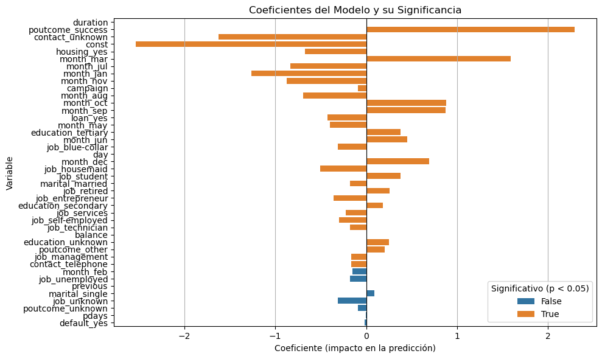

```python
# Filtrar 10 más significativas y 5 menos
top10 = summary_df[summary_df["Variable"] != "const"].sort_values("P_Valor").head(10)
bottom5 = summary_df[summary_df["Variable"] != "const"].sort_values("P_Valor", ascending=False).head(5)
plot_df = pd.concat([top10, bottom5])

# Graficar
plt.figure(figsize=(10, 6))
sns.barplot(data=summary_df.sort_values("P_Valor"),
            x="Coeficiente", y="Variable", hue="Significativo", dodge=False)

plt.axvline(0, color='black', linewidth=0.8)
plt.title("Coeficientes del Modelo y su Significancia")
plt.xlabel("Coeficiente (impacto en la predicción)")
plt.ylabel("Variable")
plt.legend(title="Significativo (p < 0.05)", loc="lower right")
plt.tight_layout()
plt.grid(True, axis='x')
plt.show()
```